# Olimpiadi della Matematica

## Finale nazionale individuale

### Cesenatico 2003 - 2024

### *Michele Bertoli*

# La gara

- 300 studenti
- 4 ore e mezza di tempo
- 6 problemi di difficoltà elevata
- Massimo 7 punti a problema

Dopo 5 anni di partecipazione sorgono alcune domande...

## Domande

1. La terza è davvero *l'anno più difficile*?
2. Come varia la difficoltà della gara nel tempo?
3. Esistono strategie per ottenere medaglie?
4. Come si evolve la carriera degli *habitué*?
5. Le rivalità tra regioni limitrofe influenzano gli esiti?  
   Quali sono le regioni più forti?

# Dati utilizzati

## Risultati della finale nazionale individuale

**Autore**: UMI (*Unione Matematica Italiana*)

**Source**:  
Anni dal **2003** al **2019**: [Medagliere](http://olimpiadi.dm.unibo.it/archivio/medagliere/)  
Anni dal **2020** al **2024**: [Tabellone 2020](http://olimpiadi.dm.unibo.it/2020/10/11/finale-nazionale-della-gara-individuale-il-tabellone/), [Tabellone 2021](http://olimpiadi.dm.unibo.it/2021/05/28/finale-nazionale-della-gara-individuale-tabellone-2021/), [Tabellone 2022](http://olimpiadi.dm.unibo.it/2022/05/09/finale-nazionale-della-gara-individuale-tabellone-2022/), [Tabellone 2023](http://olimpiadi.dm.unibo.it/2023/05/19/finale-nazionale-della-gara-individuale-tabellone-2023/), [Tabellone 2024](http://olimpiadi.dm.unibo.it/2024/05/12/cesenatico-xl-tabellone-della-gara-individuale/)

## Geografia italiana

**Autore**: Istat (*Istituto Nazionale di Statistica*)

**Source**:  
[Confini amministrativi 2024](https://www.istat.it/notizia/confini-delle-unita-amministrative-a-fini-statistici-al-1-gennaio-2018-2/)

## Informazioni disponibili

- Studente
- Regione
- Classe
- Punteggio totale
- Punteggi nei 6 esercizi
- Medaglia

*Purtroppo per alcuni anni non sono disponibili classe e regione.*

# La terza è davvero *l'anno più difficile*?

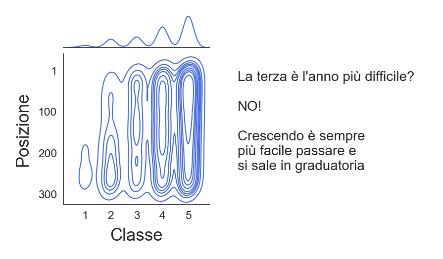

# Come varia la difficoltà della gara nel tempo?

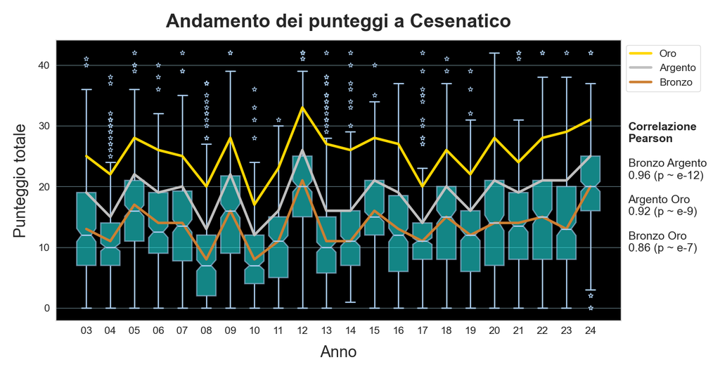

# Esistono strategie per ottenere medaglie?

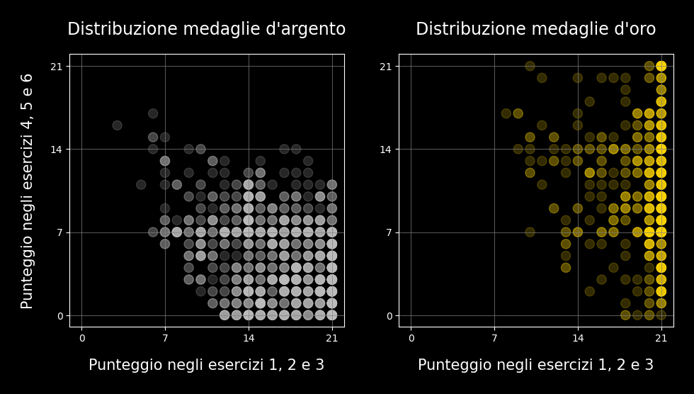

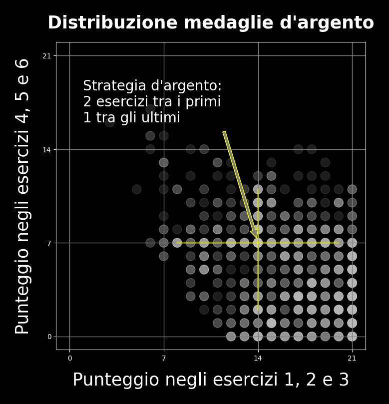

# Come si evolve la carriera degli *habitué* ?

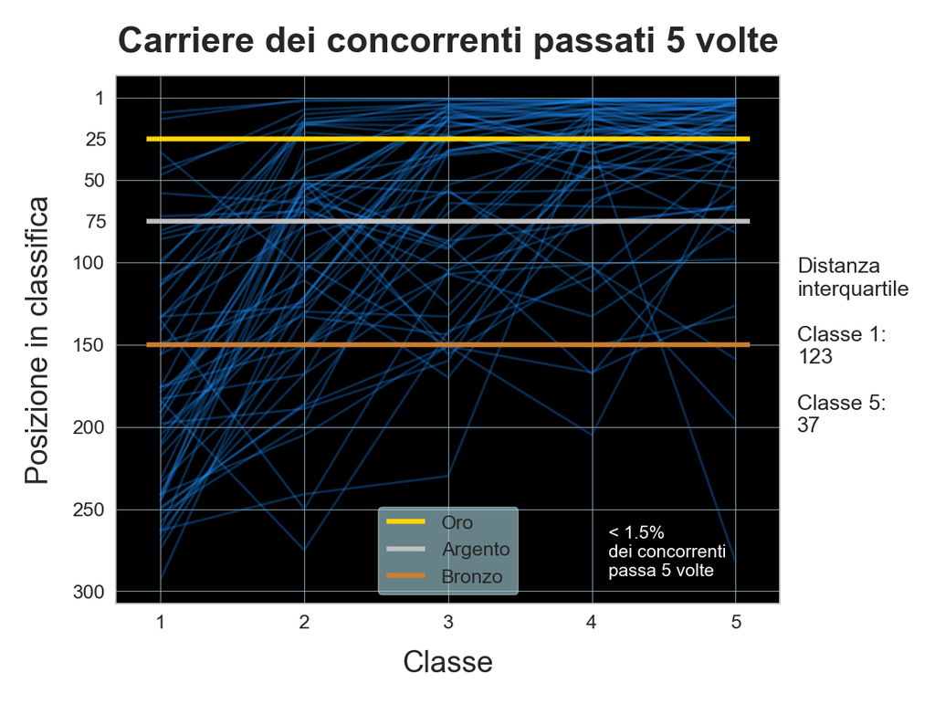

# Le rivalità tra regioni limitrofe influenzano gli esiti?

# Quali sono le regioni più forti?

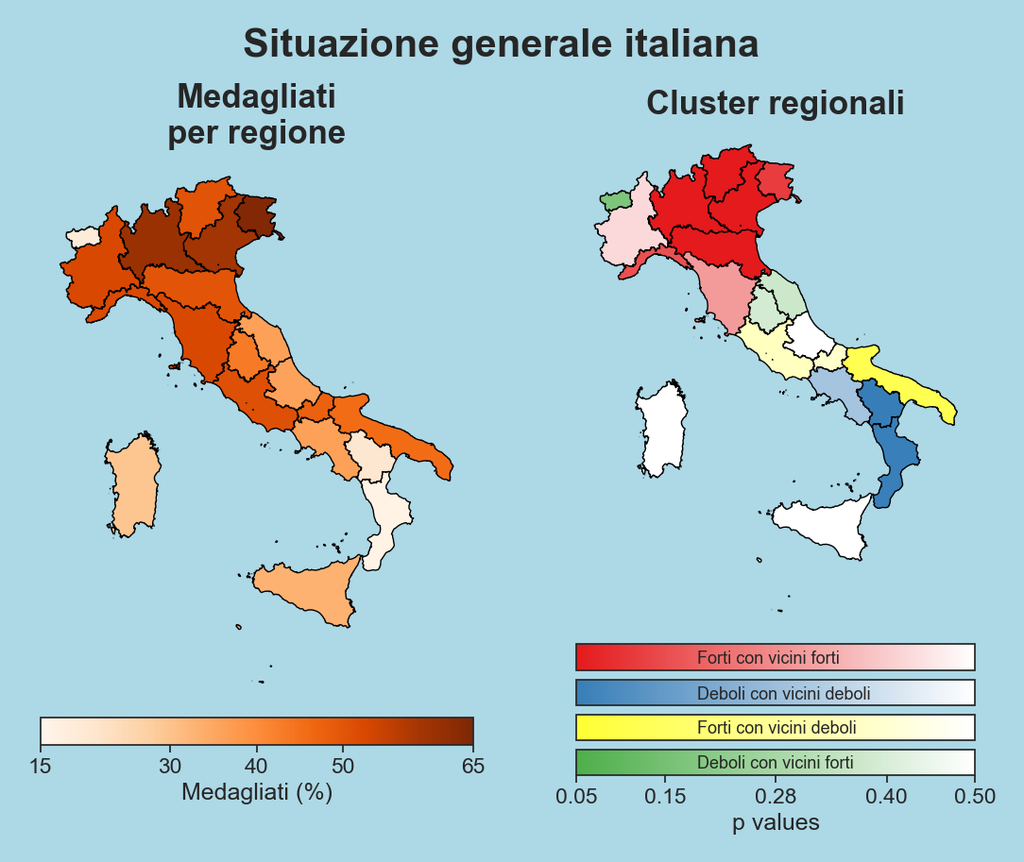

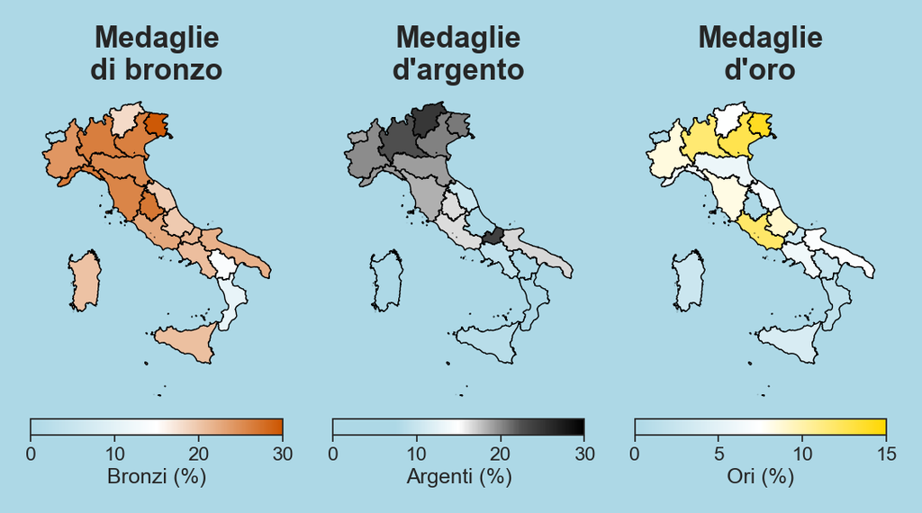

# Cosa abbiamo scoperto?

1. **La terza è davvero *l'anno più difficile*?**

   No, crescendo è sia più facile partecipare che ottenere buoni piazzamenti.
2. **Come varia la difficoltà della gara nel tempo?**

   Si alternano anni più o meno difficili.  
   Quella del 2024 sembra essere stata una gara particolarmente semplice, oppure erano più preparati i partecipanti.
3. **Esistono strategie per ottenere medaglie?**

   Per l'argento: risolvere 2 esercizi facili e 1 esercizio difficile.
4. **Come si evolve la carriera degli *habitué*?**

   Prevalentemente coronata dalla medaglia d'oro.
5. Le rivalità tra regioni limitrofe influenzano gli esiti?  
   Quali sono le regioni più forti?

   Avere vicini forti rende più forti.  
   Regioni migliori: prevalentemente regioni settentrionali, insieme a Lazio e Puglia.